# Stress Test: Preparing for the Final

2024-12-02

We will be analyzing data from an experiment where sparrows were given supplemental food (via bird feeders) 1-5 times per month for the winter months of the year; birds were given either a high (100 g) or low (25 g) amount of supplemental food.

We are testing the hypothesis that supplemental feeding allows birds to have higher body mass in the spring. Some years had harsh winters and some years were normal.

First notice that the authors manipulated/quantified supplementation in two ways:

- whether the supplement was hi (100g) or low (25g); a **categorical** measure
- how often the supplementation was given; a **continuous** measure

**Questions to work through with code, analyses, figures, models, etc.**

1. Do winter type and level of supplementation (feeding_group) work together to determine mass of sparrows? Present main and interaction effects.
2. Are differences in Spring body mass of sparrows jointly determined by winter type and feeding frequency?

If necessary, summarize the given data to produce the following charts.

```
## # A tibble: 4 × 5
## # Groups:   feeding_group [2]
##   feeding_group winter_type mean_mass     n    se
##   <chr>         <chr>           <dbl> <int> <dbl>
## 1 supp_high     harsh            32.4     8 0.728
## 2 supp_high     normal           37.7    10 1.59
## 3 supp_low      harsh            31.8    10 0.824
## 4 supp_low      normal           32.5     9 2.68
```

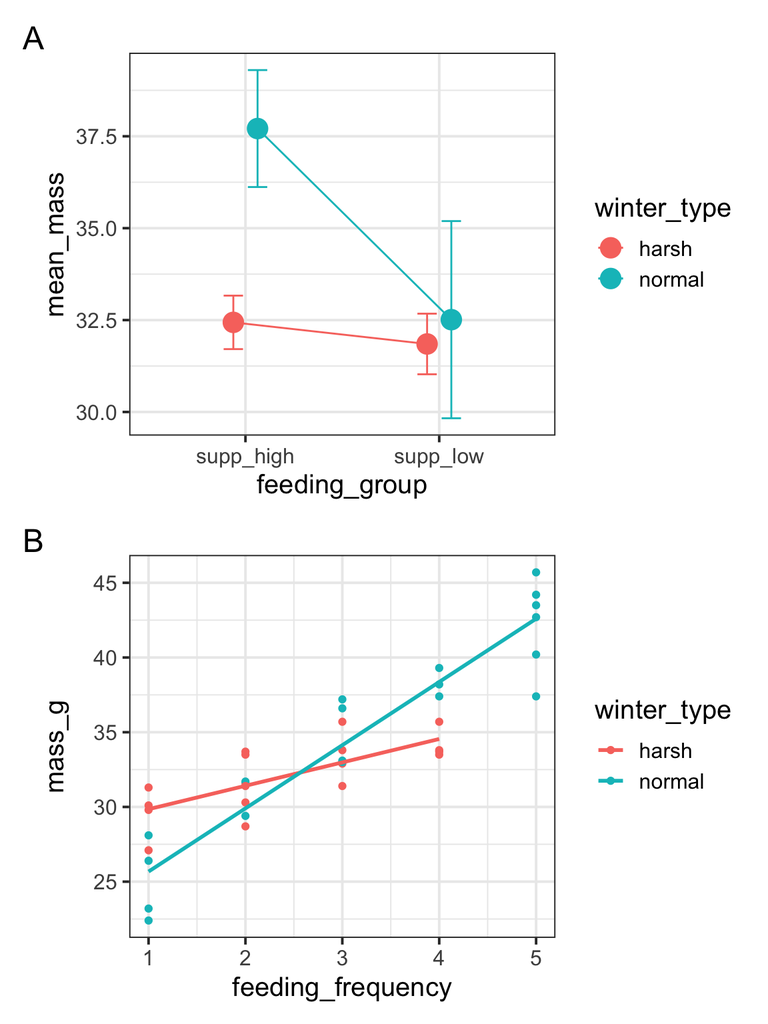

**Questions to think about in preparing for final:**

1. What are the differences in how we specify the instructions for making these **figures**?
2. What are the differences in how we **model** the data?
3. Look at the **structure** of the data (i.e. whether variables are continuous, categorical, ordinal, etc.); what kind of analysis (statistical test) would you expect from the given data structure?
4. Are there any variables you would expect to be converted to **factors**?
5. What would you expect to be the **main effects** for this analysis? How about **covariates**?
6. Would you expect any **interactions** among variables?
7. How would you visually determine whether a significant interaction is expected?
8. How do you model an interaction effect? (how is it specified in code)
9. What do significant interactions among main effects tell us?
10. What do non-significant interactions tell us?
11. If there are **no significant interaction effects** among variables, we can then proceed directly to comparing the levels of main effects **and** all possible combinations of variables to determine which is best, second-best, worst, etc.
12. If there are **significant interaction effects** among variables, we can only compare the possible combinations of variables (cannot make much inference for main effects).
13. Are there pairwise differences among levels of the main effect variables (i.e. are they different at their adjusted [marginal] means)?